# main

#### Machine learning model: Predicts the final grade label based on various features such as g1,g2,g3, age,...

##### Steps:

```
1. Collecting Data
2. Preparing Data
3. Model Selection
4. Training the Model
5. Evaluating the Model
6. Parameter Tuning
7. Prediction or Inference
```

```python
#Machine learning model: Predicts the final grade label based on various features such as g1,g2,g3, age,...

#load important libraries
import numpy as np
import pandas as pd
import matplotlib.pyplot as plt
import seaborn as sns
%matplotlib inline

from sklearn.linear_model import LinearRegression
from sklearn.model_selection import train_test_split

#suppress warnings
import warnings
warnings.filterwarnings('ignore')
```

```python
#import dataset
data = pd.read_csv('./datasets/student-mats.csv',sep=';')

#copy the dataset to avoid making any changes to the original file
df = data.copy()

#check first five rows
df.head()
```

|  | school | sex | age | address | famsize | Pstatus | Medu | Fedu | Mjob | Fjob | ... | famrel | freetime | goout | Dalc | Walc | health | absences | G1 | G2 | G3 |
| --- | --- | --- | --- | --- | --- | --- | --- | --- | --- | --- | --- | --- | --- | --- | --- | --- | --- | --- | --- | --- | --- |
| 0 | GP | F | 18 | U | GT3 | A | 4 | 4 | at_home | teacher | ... | 4 | 3 | 4 | 1 | 1 | 3 | 6 | 5 | 6 | 6 |
| 1 | GP | F | 17 | U | GT3 | T | 1 | 1 | at_home | other | ... | 5 | 3 | 3 | 1 | 1 | 3 | 4 | 5 | 5 | 6 |
| 2 | GP | F | 15 | U | LE3 | T | 1 | 1 | at_home | other | ... | 4 | 3 | 2 | 2 | 3 | 3 | 10 | 7 | 8 | 10 |
| 3 | GP | F | 15 | U | GT3 | T | 4 | 2 | health | services | ... | 3 | 2 | 2 | 1 | 1 | 5 | 2 | 15 | 14 | 15 |
| 4 | GP | F | 16 | U | GT3 | T | 3 | 3 | other | other | ... | 4 | 3 | 2 | 1 | 2 | 5 | 4 | 6 | 10 | 10 |

5 rows × 33 columns

```python
#check rows, cols
df.shape
```

```
(395, 33)
```

```python
#check colmns, count, missing values

df.info()
```

```
<class 'pandas.core.frame.DataFrame'>
RangeIndex: 395 entries, 0 to 394
Data columns (total 33 columns):
 #   Column      Non-Null Count  Dtype
---  ------      --------------  -----
 0   school      395 non-null    object
 1   sex         395 non-null    object
 2   age         395 non-null    int64
 3   address     395 non-null    object
 4   famsize     395 non-null    object
 5   Pstatus     395 non-null    object
 6   Medu        395 non-null    int64
 7   Fedu        395 non-null    int64
 8   Mjob        395 non-null    object
 9   Fjob        395 non-null    object
```

[output cut: 25 more lines]

Now, we made sure there are no missing values in the data. Columns we found important for grade prediction are age, studytime, absences, g1,g2,g3

```python
df = df[['age','sex','studytime','absences','G1','G2','G3']]

df
```

|  | age | sex | studytime | absences | G1 | G2 | G3 |
| --- | --- | --- | --- | --- | --- | --- | --- |
| 0 | 18 | F | 2 | 6 | 5 | 6 | 6 |
| 1 | 17 | F | 2 | 4 | 5 | 5 | 6 |
| 2 | 15 | F | 2 | 10 | 7 | 8 | 10 |
| 3 | 15 | F | 3 | 2 | 15 | 14 | 15 |
| 4 | 16 | F | 2 | 4 | 6 | 10 | 10 |
| ... | ... | ... | ... | ... | ... | ... | ... |
| 390 | 20 | M | 2 | 11 | 9 | 9 | 9 |
| 391 | 17 | M | 1 | 3 | 14 | 16 | 16 |
| 392 | 21 | M | 1 | 3 | 10 | 8 | 7 |
| 393 | 18 | M | 1 | 0 | 11 | 12 | 10 |
| 394 | 19 | M | 1 | 5 | 8 | 9 | 9 |

395 rows × 7 columns

The columns G1, G2, G3 are three grades that a student can get. The goal is to predict the final grade by looking at other variables.

G3 in this case will be our label and rest all are the features. Each feature is an axis in the coordinate system and each point is a record, that is, one row in the table.

The problem here is that the feature 'sex' is not numeric but categorical. For us to register it in the coordinate system, we need to first convert it to numeric.

```python
#covert to numeric using map function to map the categories to thier respective number equivalents
df['sex']=data['sex'].map({'F':0,'M':1})

#define the desired label of the variable
prediction = 'G3'
```

[output not shown]

Now, our data is fully loaded and selected.

However, in order to use it as training and testing data for our model, we have to reformat them. It is because the sklearn models won't accept pandas data frames.

They only accept numpy arrays.

So, we will apply this to our features. We will turn our features into x-array and our label into y-array.

```python
#returns the data frame without specified column
X = np.array(df.drop([prediction],1))
#the x array now has all our columns except the final grade, which is in y array

Y = np.array(df[prediction])

#to train and test, we need to split the data.

# we use the first part to get the hyperplane to fit our data
# second part to check the accuracy of the prediction

X_train, X_test, Y_train, Y_test = train_test_split(X,Y,test_size = 0.1)

# we divided the x and y arrays into four arrays. The test size specifies what percentage of records to use. Here, it is 10%
# 10% is a recommended value

#now we start training and testing our model

model = LinearRegression()

#pass our training data
model.fit(X_train,Y_train)

#it has now adjusted its hyperplane so that it fits all our values
#to test the model performance, we use the score method

accuracy = model.score(X_test,Y_test)

print(accuracy)

#the results will be different at each run as the training and test data is always random. Do this until you get above 90 percent
# that is a good percentage
```

```
0.9148912631154704
```

After several iterations, we got 91 %.

Now that we know that our model is reliable, we can pass new data and predict the final grade

```python
X_new = np.array([[18,1,3,40,15,16]])

Y_new = model.predict(X_new)
print(Y_new)
```

```
[17.38816219]
```

Here, the final grade is 17 based on the features passed.

We now visualize the relationship between individual features

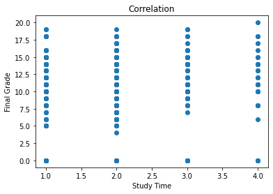

```python
plt.scatter(df['studytime'],df['G3'])
plt.title("Correlation")
plt.xlabel("Study Time")
plt.ylabel("Final Grade")

plt.show()
```

Here, we tried to see the relationship between the learning time and final grade. As we can see, there is no strong relationship. The data is diverse and there is no clear pattern

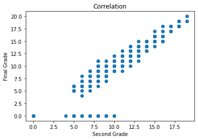

```python
#Let's take G2 and G3
plt.scatter(df['G2'],df['G3'])
plt.title("Correlation")
plt.xlabel("Second Grade")
plt.ylabel("Final Grade")

plt.show()
```

If we look at the correlation between the second grade and the third grade, there is a strong correlation.

#### Apparently, we can conclude that students with good second grades are likely to end up with a good final grade as well.

Note:

This example is taken from: *The Python Bible 7 in 1: Volumes One To Seven (Beginner, Intermediate, Data Science, Machine Learning, Finance, Neural Networks, Computer Vision).

Author: Dedov, Florian.